# GEO 200CN Lab 7

Kenneth Larrieu

May 13, 2019

## ISLR Ch. 5 Question 5

5. In Chapter 4, we used logistic regression to predict the probability of `default` using `income` and `balance` on the `Default` data set. We will now estimate the test error of this logistic regression model using the validation set approach. Do not forget to set a random seed before beginning your analysis.
1. Fit a logistic regression model that uses `income` and `balance` to predict `default`.

```r
set.seed(12345)
# load input data
library(ISLR)
def = ISLR::Default
# fit a logistic regression model
glm.fit = glm(default~income+balance, data=def, family=binomial)
summary(glm.fit)
```

```
##
## Call:
## glm(formula = default ~ income + balance, family = binomial,
##     data = def)
##
## Deviance Residuals:
##     Min       1Q   Median       3Q      Max
## -2.4725  -0.1444  -0.0574  -0.0211   3.7245
##
## Coefficients:
##               Estimate Std. Error z value Pr(>|z|)
## (Intercept) -1.154e+01  4.348e-01 -26.545  < 2e-16 ***
## income       2.081e-05  4.985e-06   4.174 2.99e-05 ***
## balance      5.647e-03  2.274e-04  24.836  < 2e-16 ***
## ---
## Signif. codes:  0 '***' 0.001 '**' 0.01 '*' 0.05 '.' 0.1 ' ' 1
##
## (Dispersion parameter for binomial family taken to be 1)
##
##     Null deviance: 2920.6  on 9999  degrees of freedom
## Residual deviance: 1579.0  on 9997  degrees of freedom
## AIC: 1585
##
## Number of Fisher Scoring iterations: 8
```

2. Using the validation set approach, estimate the test error of this model. In order to do this, you must perform the following steps:
- 1. Split the sample set into a training set and a validation set.

```r
library(dismo)
# partition the data set
k = kfold(def, k=2)
train = def[k == 1,]
test = def[k == 2,]
```

-ii. Fit a multiple logistic regression model using only the training observations.

```r
# fit logistic regression on training data
glm.fit = glm(default~income+balance, data=train, family=binomial)
summary(glm.fit)
```

```
##
## Call:
## glm(formula = default ~ income + balance, family = binomial,
##     data = train)
##
## Deviance Residuals:
##     Min       1Q   Median       3Q      Max
## -2.3810  -0.1468  -0.0607  -0.0236   3.6935
##
## Coefficients:
##               Estimate Std. Error z value Pr(>|z|)
## (Intercept) -1.122e+01  6.059e-01 -18.524  < 2e-16 ***
## income       1.844e-05  7.141e-06   2.582  0.00982 **
## balance      5.467e-03  3.149e-04  17.357  < 2e-16 ***
## ---
## Signif. codes:  0 '***' 0.001 '**' 0.01 '*' 0.05 '.' 0.1 ' ' 1
##
## (Dispersion parameter for binomial family taken to be 1)
##
##     Null deviance: 1423.08  on 4999  degrees of freedom
## Residual deviance:  793.25  on 4997  degrees of freedom
## AIC: 799.25
##
## Number of Fisher Scoring iterations: 8
```

-iii. Obtain a prediction of default status for each individual in the validation set by computing the posterior probability of default for that individual, and classifying the individual to the default category if the posterior probability is greater than 0.5.

```r
# get posterior probabilities for test data
pred_probs = predict(glm.fit, test, type='response')
pred_probs = as.matrix(pred_probs)
# function determines whether default or not based on probability
yesno = function(p){
  if (p>0.5){
    'Yes'
  }
  else{
    'No'
  }
}
# make column of predicted default on test data set
test$def_pred = apply(pred_probs, 1, yesno)
```

-iv. Compute the validation set error, which is the fraction of the observations in the validation set that are misclassified.

```r
# misclassification rate
sum(test$default != test$def_pred)/nrow(test)
```

```
## [1] 0.0276
```

3. Repeat the process in (b) three times, using three different splits of the observations into a training set and a validation set. Comment on the results obtained.

```r
# make a function to repeat the process for a given sampling seed
err_rate = function(seed){
  set.seed(seed)
  k = kfold(def, k=2)
  train = def[k == 1,]
  test = def[k == 2,]
  glm.fit = glm(default~income+balance, data=train, family=binomial)
  pred_probs = predict(glm.fit, test, type='response')
  pred_probs = as.matrix(pred_probs)
  test$def_pred = apply(pred_probs, 1, yesno)

  sum(test$default != test$def_pred)/nrow(test)
}

# get misclassification rates for seeds 1:3
apply(as.matrix(c(1:3)), 1, FUN=err_rate)
```

```
## [1] 0.0258 0.0260 0.0282
```

So based on the observed misclassification rates, it is typically in the range of 2.6-2.8%, suggesting a relatively low variance of our validation error rate for different samplings.

4. Now consider a logistic regression model that predicts the probability of `default` using `income`, `balance`, and a dummy variable for `student`. Estimate the test error for this model using the validation set approach. Comment on whether or not including a dummy variable for `student` leads to a reduction in the test error rate.

```r
# converts yes/no to binary variable
bin = function(string){
  if (string=='Yes'){
    1
  }
  else{
    0
  }
}

# add studentvar binary variable to our data set
def$studentvar = apply(as.matrix(def$student), 1, FUN=bin)

# same as err_rate function but with studentvar added to model
err_rate2 = function(seed){
  set.seed(seed)
  k = kfold(def, k=2)
  train = def[k == 1,]
  test = def[k == 2,]
  glm.fit = glm(default~income+balance+studentvar, data=train, family=binomial)

  pred_probs = predict(glm.fit, test, type='response')
  pred_probs = as.matrix(pred_probs)
  test$def_pred = apply(pred_probs, 1, yesno)
  sum(test$default != test$def_pred)/nrow(test)
}

apply(as.matrix(1:3), 1, err_rate2)
```

```
## [1] 0.0262 0.0264 0.0284
```

Now we see that adding the dummy variable for `student` actually led to a slight increase in our misclassification rates for all seeds 1-3. This may suggest that this model is more biased towards the training data.

## Part 2: ISLR Chapter 7

```r
d = read.csv('temperature.csv')
head(d)
```

```
##      ID             NAME     LONG    LAT  ALT  JAN  FEB  MAR  APR  MAY
## 1 19303 PARKER-RESERVOIR -114.166 34.283  225 11.9 14.8 17.8 21.9 26.8
## 2 19335    IRON-MOUNTAIN -115.133 34.133  281 12.2 14.8 17.5 21.6 26.4
## 3 19343   EAGLE-MOUNTAIN -115.450 33.800  297 12.6 15.2 17.7 21.6 26.1
## 4 19347 MITCHELL-CAVERNS -115.533 34.933 1326  7.8  9.4 10.9 14.8 19.6
## 5 19348    MOUNTAIN-PASS -115.533 35.466 1442  3.9  5.8  8.1 11.9 16.7
## 6 19349  EL-CENTRO-2-SSW -115.566 32.766   -9 12.6 14.9 17.2 20.3 24.7
##    JUN  JUL  AUG  SEP  OCT  NOV  DEC
## 1 32.1 35.2 34.3 30.8 24.6 17.2 12.2
## 2 31.7 34.9 33.8 30.0 23.9 17.0 12.3
## 3 31.4 34.2 33.4 30.0 24.2 17.5 13.0
## 4 25.1 28.2 27.0 23.6 18.4 12.0  8.1
## 5 22.6 26.3 25.0 21.1 15.0  8.7  4.2
## 6 29.5 32.9 32.7 29.3 23.6 16.9 12.5
```

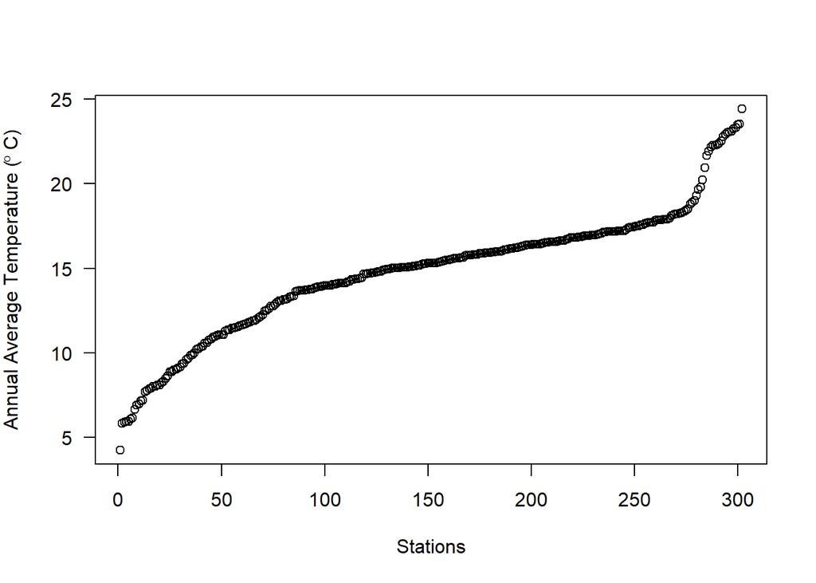

```r
# get average annual temperature
d$temp = rowMeans(d[,c(6:17)])
plot(sort(d$temp), ylab=expression('Annual Average Temperature ('~degree~'C)'), las=1, xlab='Stations')
```

```r
library(raster)
CA <- shapefile("counties_2000.shp")
# make points for each location
dsp = SpatialPoints(d[,3:4], proj4string=CRS('+proj=longlat +datum=NAD83'))
# combine with data frame
dsp = SpatialPointsDataFrame(dsp, d)
dsp
```

```
## class       : SpatialPointsDataFrame
## features    : 302
## extent      : -124.233, -114.166, 32.57, 41.966  (xmin, xmax, ymin, ymax)
## coord. ref. : +proj=longlat +datum=NAD83 +ellps=GRS80 +towgs84=0,0,0
## variables   : 18
## names       :    ID,                NAME,     LONG,    LAT,  ALT,  JAN,  FEB,  MAR,  APR,  MAY,  JUN,  JUL,  AUG,  SEP,  OCT, ...
## min values  : 19303, ADIN-RANGER-STATION, -114.166, 32.570,  -13, -0.2, -0.6, -1.9,  0.9,  5.1,  9.9, 13.6, 13.6, 10.4,  6.1, ...
## max values  : 24549,        YUMA ARIZONA, -124.233, 41.966, 2438, 14.7, 16.0, 19.3, 24.0, 29.3, 34.6, 38.2, 37.2, 32.2, 25.5, ...
```

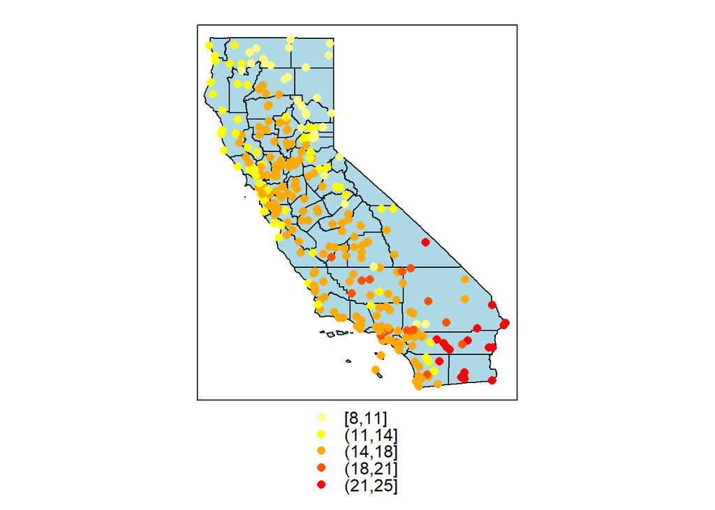

```r
cuts <- c(8,11,14,18,21,25)
pols <- list("sp.polygons", CA, fill = "lightblue")
print(spplot(dsp, 'temp', cuts=cuts, sp.layout=pols,
col.regions=rev(heat.colors(5))))
```

### Null Model

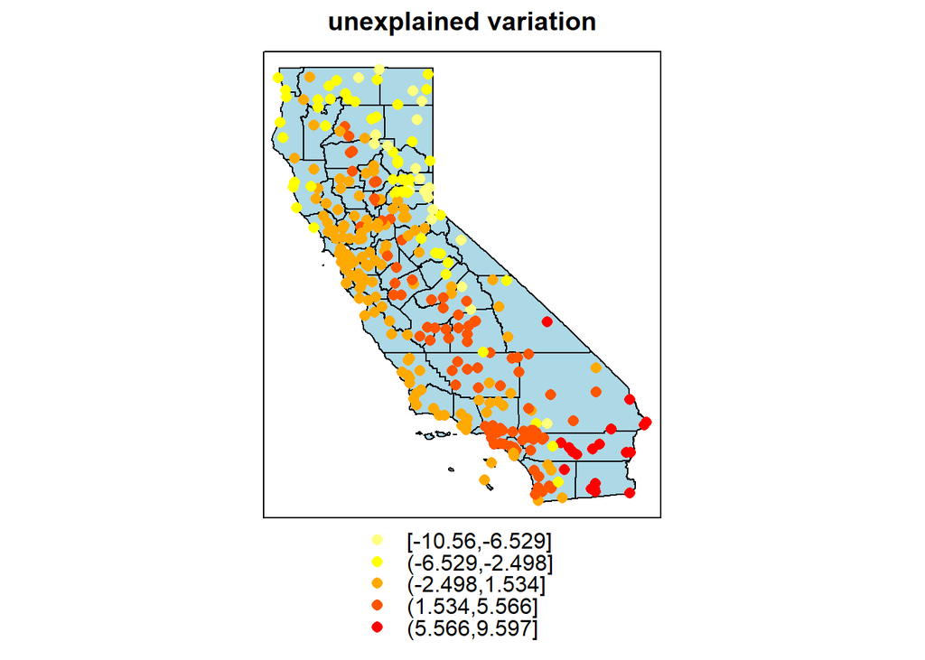

```r
# use the mean average annual temp as a null model
tavg = mean(d$temp)
# local deviations from the mean
dsp$diff = dsp$temp - tavg

print(spplot(dsp, 'diff', col.regions=rev(heat.colors(5)),
sp.layout=pols, main = "unexplained variation" ))
```

Computing RMSE for the null model:

```r
RMSE = function(observed, predicted){
  sqrt(mean((predicted-observed)^2, na.rm=TRUE))
}

RMSE(d$temp, tavg)
```

```
## [1] 3.722373
```

```r
# transform data to Teale-Albers
TA <- CRS(" +proj=aea +lat_1=34 +lat_2=40.5 +lat_0=0 +lon_0=-120 +x_0=0
+y_0=-4000000 +datum=NAD83 +units=m +no_defs +ellps=GRS80 +towgs84=0,0,0")
library(rgdal)
dta <- spTransform(dsp, TA)
cata <- spTransform(CA, TA)

# set sampling for cross-validation
set.seed(5162016)
library(dismo)
k <- kfold(dta)
table(k)
```

```
## k
##  1  2  3  4  5
## 60 61 60 61 60
```

```r
test <- dta[k==1, ]
train <- dta[k!=1, ]
```

## Linear Model

```r
# make training dataframe of coordinates and temp
df <- data.frame(coordinates(train), temp=train$temp)
colnames(df)[1:2] = c('x', 'y')

# fit temp as linear function of x and y coords
m <- glm(temp ~ x+y, data=df)
summary(m)
```

```
##
## Call:
## glm(formula = temp ~ x + y, data = df)
##
## Deviance Residuals:
##     Min       1Q   Median       3Q      Max
## -9.5810  -1.5613   0.1474   1.8181   8.8619
##
## Coefficients:
##               Estimate Std. Error t value Pr(>|t|)
## (Intercept)  1.390e+01  2.135e-01  65.073  < 2e-16 ***
## x            7.109e-07  1.521e-06   0.467    0.641
## y           -8.675e-06  1.100e-06  -7.887  1.1e-13 ***
## ---
## Signif. codes:  0 '***' 0.001 '**' 0.01 '*' 0.05 '.' 0.1 ' ' 1
##
## (Dispersion parameter for gaussian family taken to be 8.236277)
##
##     Null deviance: 3579.8  on 241  degrees of freedom
## Residual deviance: 1968.5  on 239  degrees of freedom
## AIC: 1202
##
## Number of Fisher Scoring iterations: 2
```

**Question 2:** Describe (in statistical terms) and explain (in physical terms) the results shown by `summary(m)`.

The results show that for a linear model the average annual temperature has a non-significant dependence on the x coordinate, while there is a significant dependence on the y coordinate. This indicates physically that the average annual temperature does not vary significantly with longitude, and because the y coefficient is negative, it indicates that at lower y values (i.e. latitudes closer to the equator) the temperatures are typically warmer and vice versa. This agrees with expectations because the Mojave Desert is in the south and typically hotter.

**Question 3:** According to this model. How much does the temperature in California change if you travel 500 miles to the north (show the R code to compute that)

```r
coefficients(m)[['y']]*500*1609.34 # degrees/m * mi * m/mi
```

```
## [1] -6.980608
```

So according to the model, the temperature decreases by approximately 6.98 degrees C when one travels 500 miles north.

```r
# predict on the test data
v <- data.frame(coordinates(test))
colnames(v)[1:2] = c('x', 'y')
p <- predict(m, v)

# compare RMSE for null and linear models
# null model
RMSE(mean(train$temp), test$temp)
```

```
## [1] 3.179886
```

```r
# linear model
RMSE(p, test$temp)
```

```
## [1] 2.84847
```

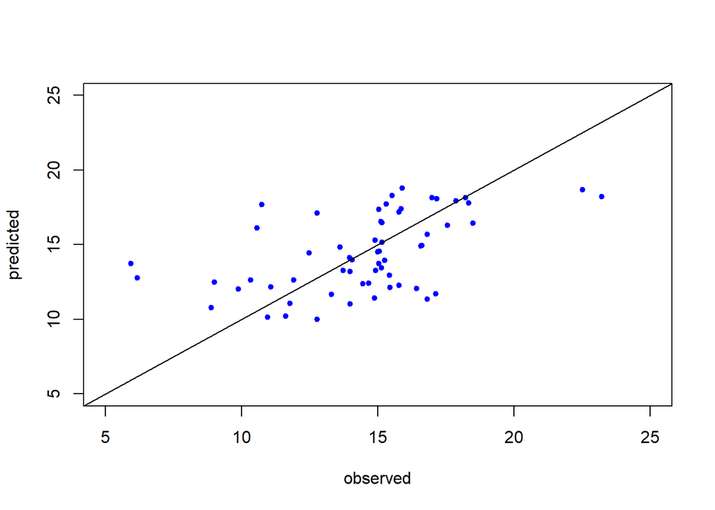

```r
# plot observed vs. predicted test data temps
plot(test$temp, p, xlim=c(5,25), ylim=c(5,25), pch=20,
col='blue', xlab='observed', ylab='predicted')
# for reference: y=x
abline(0,1)
```

```r
# 5-fold cross-validation
r <- rep(NA,5)
for (i in 1:5) {
test <- dta[k==i, ]
train <- dta[k!=i, ]
df <- data.frame(coordinates(train), temp=train$temp)
m <- glm(temp ~ ., data=df)
v <- data.frame(coordinates(test))
p <- predict(m, v)
r[i] <- RMSE(p, test$temp)
}
r
```

```
## [1] 2.848470 3.227967 2.675434 2.819683 2.757730
```

```r
mean(r)
```

```
## [1] 2.865857
```

**Question 4:** Was it important to do 5-fold cross-validation, instead of a single 20-80 split?

Although in this case the first test RMSE was very close to the average, it is always preferred to dp the full 5-fold cross validation over a single 20-80 split because it provides a more reliable estimate of the model performance given different sample subsets of the data. For example, if the second training/test sets alone had been used, it would have estimated test RMSE as 3.22, which could give a false impression that the linear model performs worse than the null model.

Now predicting values for grid cells:

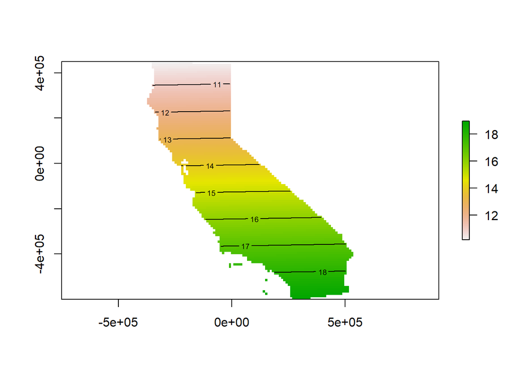

```r
# create 10km resolution raster
r <- raster(round(extent(cata)), res=10000, crs=TA)

# get the x coordinates
x <- init(r, v='x')
# set areas outside of CA to NA
x <- mask(x, cata)
# get the y coordinates
y <- init(r, v='y')
# combine the two variables (RasterLayers)
s <- stack(x,y)
names(s) <- c('x', 'y')

df <- data.frame(coordinates(dta), temp=dta$temp)
colnames(df)[1:2] = c('x', 'y')
m <- glm(temp ~ ., data=df)

# can use interpolate instead of predict since it knows to use coordinates
z <- interpolate(r, m)
mask <- mask(z, cata)
zm <- mask(z, mask)
plot(zm)
contour(zm, add=TRUE)
```

```r
# alternative model with interaction terms
df <- data.frame(coordinates(dta), temp=dta$temp)
colnames(df)[1:2] = c('x', 'y')
test <- df[k==1, ]
train <- df[k!=1, ]
m <- glm(temp ~ x*y, data=train)
summary(m)
```

```
##
## Call:
## glm(formula = temp ~ x * y, data = train)
##
## Deviance Residuals:
##     Min       1Q   Median       3Q      Max
## -9.6890  -1.6651   0.0988   2.0840   9.7998
##
## Coefficients:
##               Estimate Std. Error t value Pr(>|t|)
## (Intercept)  1.325e+01  2.864e-01  46.275  < 2e-16 ***
## x           -2.845e-06  1.841e-06  -1.545  0.12371
## y           -9.210e-06  1.090e-06  -8.448 2.97e-15 ***
## x:y         -1.306e-11  3.969e-12  -3.290  0.00115 **
## ---
## Signif. codes:  0 '***' 0.001 '**' 0.01 '*' 0.05 '.' 0.1 ' ' 1
##
## (Dispersion parameter for gaussian family taken to be 7.91116)
##
##     Null deviance: 3579.8  on 241  degrees of freedom
## Residual deviance: 1882.9  on 238  degrees of freedom
## AIC: 1193.3
##
## Number of Fisher Scoring iterations: 2
```

```r
# check AIC and RMSE
AIC(m)
```

```
## [1] 1193.255
```

```r
RMSE(predict(m, test), test$temp)
```

```
## [1] 2.591301
```

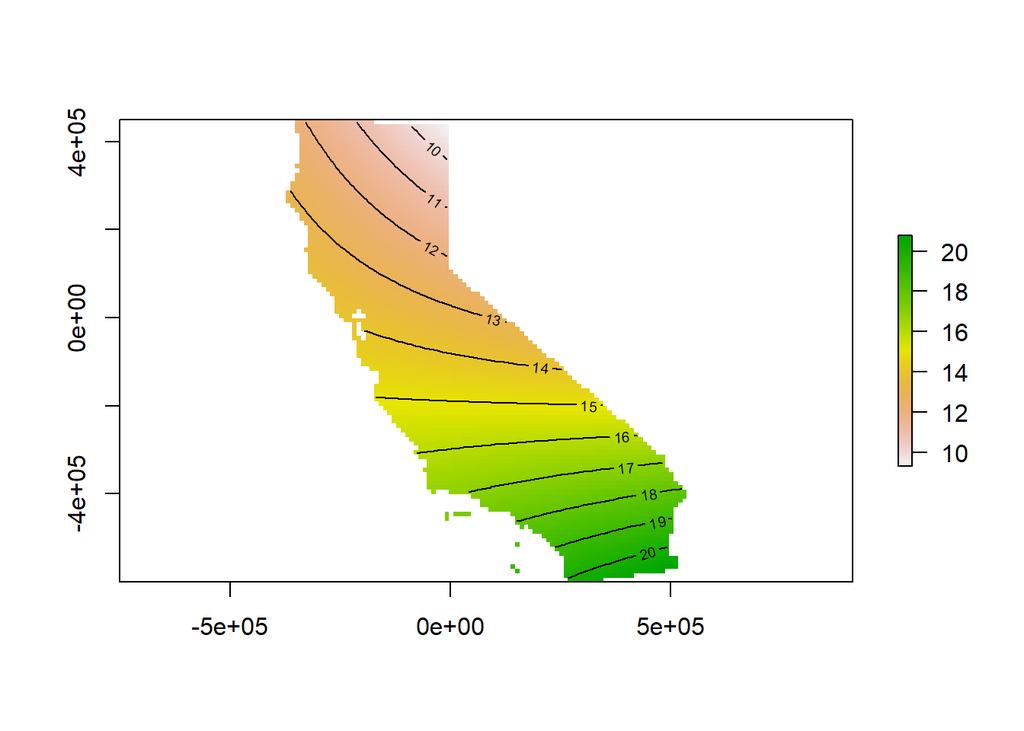

```r
# plot the model predictions
z <- interpolate(r, m)
zm <- mask(z, mask)
plot(zm)
contour(zm, add=TRUE)
```

```r
# another alternative model with polynomial terms
m <- glm(temp ~ x + y + I(x^2) + I(y^2), data=df)
summary(m)
```

```
##
## Call:
## glm(formula = temp ~ x + y + I(x^2) + I(y^2), data = df)
##
## Deviance Residuals:
##     Min       1Q   Median       3Q      Max
## -9.6891  -1.0553   0.0012   1.7994   7.8593
##
## Coefficients:
##               Estimate Std. Error t value Pr(>|t|)
## (Intercept)  1.340e+01  2.681e-01  49.986  < 2e-16 ***
## x           -2.003e-06  1.389e-06  -1.443     0.15
## y           -9.938e-06  9.116e-07 -10.903  < 2e-16 ***
## I(x^2)       2.935e-11  3.480e-12   8.433 1.49e-15 ***
## I(y^2)      -9.097e-12  2.221e-12  -4.095 5.44e-05 ***
## ---
## Signif. codes:  0 '***' 0.001 '**' 0.01 '*' 0.05 '.' 0.1 ' ' 1
##
## (Dispersion parameter for gaussian family taken to be 6.592786)
##
##     Null deviance: 4184.5  on 301  degrees of freedom
## Residual deviance: 1958.1  on 297  degrees of freedom
## AIC: 1433.6
##
## Number of Fisher Scoring iterations: 2
```

```r
AIC(m)
```

```
## [1] 1433.562
```

```r
RMSE(predict(m, test), test$temp)
```

```
## [1] 2.57128
```

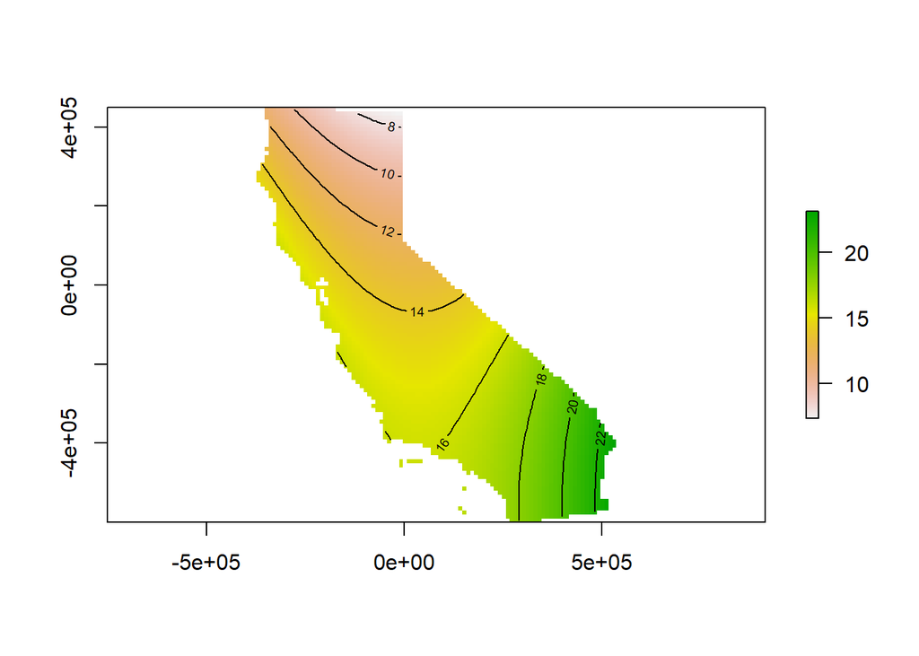

```r
z <- interpolate(r, m)
zm <- mask(z, mask)
plot(zm)
contour(zm, add=TRUE)
```

```r
# second-order polynomials and interaction terms
m <- glm(temp ~ poly(x, 2, raw=TRUE) * poly(y, 2, raw=TRUE), data=train)
summary(m)
```

```
##
## Call:
## glm(formula = temp ~ poly(x, 2, raw = TRUE) * poly(y, 2, raw = TRUE),
##     data = train)
##
## Deviance Residuals:
##      Min        1Q    Median        3Q       Max
## -10.3522   -0.9868    0.2307    1.4750   10.1212
##
## Coefficients:
##                                                   Estimate Std. Error
## (Intercept)                                      1.361e+01  3.342e-01
## poly(x, 2, raw = TRUE)1                         -1.294e-05  3.036e-06
## poly(x, 2, raw = TRUE)2                         -3.536e-11  1.283e-11
## poly(y, 2, raw = TRUE)1                         -1.585e-05  1.477e-06
## poly(y, 2, raw = TRUE)2                         -2.907e-11  4.788e-12
## poly(x, 2, raw = TRUE)1:poly(y, 2, raw = TRUE)1 -8.756e-11  1.773e-11
## poly(x, 2, raw = TRUE)2:poly(y, 2, raw = TRUE)1 -1.575e-16  4.154e-17
## poly(x, 2, raw = TRUE)1:poly(y, 2, raw = TRUE)2 -9.535e-17  2.484e-17
## poly(x, 2, raw = TRUE)2:poly(y, 2, raw = TRUE)2 -8.389e-23  6.091e-23
##                                                 t value Pr(>|t|)
## (Intercept)                                      40.732  < 2e-16 ***
## poly(x, 2, raw = TRUE)1                          -4.262 2.95e-05 ***
## poly(x, 2, raw = TRUE)2                          -2.757 0.006298 **
## poly(y, 2, raw = TRUE)1                         -10.731  < 2e-16 ***
## poly(y, 2, raw = TRUE)2                          -6.072 5.08e-09 ***
## poly(x, 2, raw = TRUE)1:poly(y, 2, raw = TRUE)1  -4.940 1.49e-06 ***
## poly(x, 2, raw = TRUE)2:poly(y, 2, raw = TRUE)1  -3.790 0.000192 ***
## poly(x, 2, raw = TRUE)1:poly(y, 2, raw = TRUE)2  -3.838 0.000160 ***
## poly(x, 2, raw = TRUE)2:poly(y, 2, raw = TRUE)2  -1.377 0.169736
## ---
## Signif. codes:  0 '***' 0.001 '**' 0.01 '*' 0.05 '.' 0.1 ' ' 1
##
## (Dispersion parameter for gaussian family taken to be 5.947476)
##
##     Null deviance: 3579.8  on 241  degrees of freedom
## Residual deviance: 1385.8  on 233  degrees of freedom
## AIC: 1129.1
##
## Number of Fisher Scoring iterations: 2
```

```r
AIC(m)
```

```
## [1] 1129.073
```

```r
RMSE(predict(m, test), test$temp)
```

```
## [1] 2.313966
```

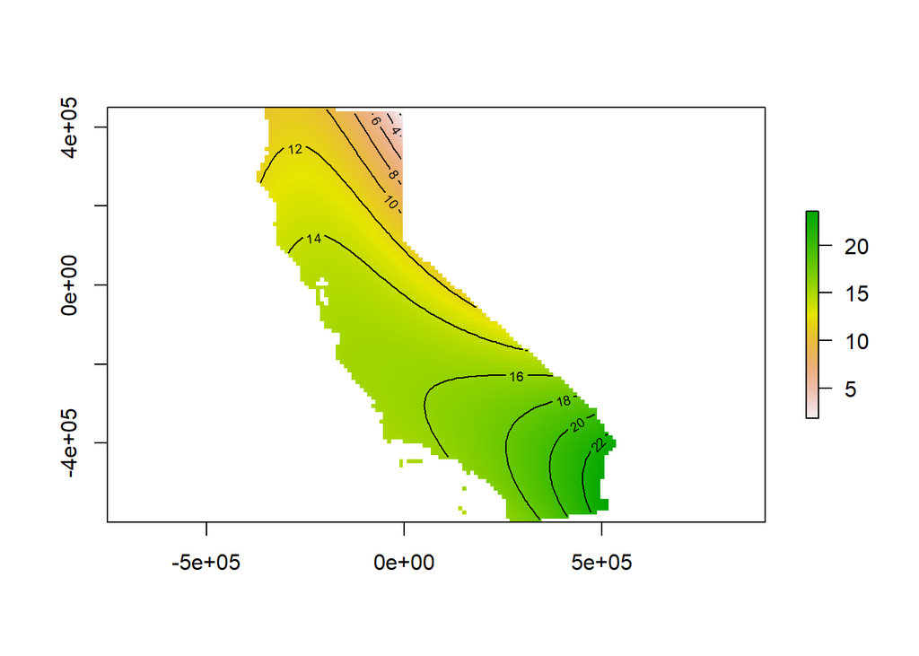

```r
z <- interpolate(r, m)
zm <- mask(z, mask)
plot(zm)
contour(zm, add=TRUE)
```

**Question 5:** What is the best model so far? Why?

The model with second order polynomials and interaction terms is the best model so far, because it has the lowest test RMSE as well as the lowest AIC.

**Question 6:** Rerun the last model using (a) ridge regression, and (b) lasso regression. Show the changes in coefficients for three values of lambda; by finishing the code below.

```r
f <- temp ~ poly(x, 2, raw=TRUE) * poly(y, 2, raw=TRUE)
x <- model.matrix(f, df)
library(glmnet)
lambdas = 10^c(-3, 0, 3)

# ridge regression
gr <- glmnet(x, df$temp, alpha=0, lambda=lambdas)


# lasso regression
gl <- glmnet(x, df$temp, alpha=1, lambda=lambdas)

coef(gr)
```

```
## 10 x 3 sparse Matrix of class "dgCMatrix"
##                                                            s0
## (Intercept)                                      1.478462e+01
## (Intercept)                                      .
## poly(x, 2, raw = TRUE)1                          3.504090e-08
## poly(x, 2, raw = TRUE)2                          1.236974e-13
## poly(y, 2, raw = TRUE)1                         -3.100259e-08
## poly(y, 2, raw = TRUE)2                          4.876673e-14
## poly(x, 2, raw = TRUE)1:poly(y, 2, raw = TRUE)1 -9.758822e-14
## poly(x, 2, raw = TRUE)2:poly(y, 2, raw = TRUE)1 -3.000033e-19
## poly(x, 2, raw = TRUE)1:poly(y, 2, raw = TRUE)2  2.270632e-19
## poly(x, 2, raw = TRUE)2:poly(y, 2, raw = TRUE)2  5.502858e-25
##                                                            s1
## (Intercept)                                      1.379782e+01
## (Intercept)                                      .
## poly(x, 2, raw = TRUE)1                          2.765269e-07
## poly(x, 2, raw = TRUE)2                          1.219426e-11
## poly(y, 2, raw = TRUE)1                         -5.145714e-06
## poly(y, 2, raw = TRUE)2                         -5.027329e-12
## poly(x, 2, raw = TRUE)1:poly(y, 2, raw = TRUE)1 -3.117050e-12
## poly(x, 2, raw = TRUE)2:poly(y, 2, raw = TRUE)1 -1.362514e-17
## poly(x, 2, raw = TRUE)1:poly(y, 2, raw = TRUE)2  7.199096e-18
## poly(x, 2, raw = TRUE)2:poly(y, 2, raw = TRUE)2  1.291548e-23
##                                                            s2
## (Intercept)                                      1.339668e+01
## (Intercept)                                      .
## poly(x, 2, raw = TRUE)1                         -1.520503e-05
## poly(x, 2, raw = TRUE)2                         -4.063497e-11
## poly(y, 2, raw = TRUE)1                         -1.606166e-05
## poly(y, 2, raw = TRUE)2                         -2.912270e-11
## poly(x, 2, raw = TRUE)1:poly(y, 2, raw = TRUE)1 -9.845121e-11
## poly(x, 2, raw = TRUE)2:poly(y, 2, raw = TRUE)1 -1.791257e-16
## poly(x, 2, raw = TRUE)1:poly(y, 2, raw = TRUE)2 -1.032024e-16
## poly(x, 2, raw = TRUE)2:poly(y, 2, raw = TRUE)2 -1.118925e-22
```

```r
coef(gl)
```

```
## 10 x 3 sparse Matrix of class "dgCMatrix"
##                                                       s0            s1
## (Intercept)                                     14.81087  1.412620e+01
## (Intercept)                                      .        .
## poly(x, 2, raw = TRUE)1                          .        .
## poly(x, 2, raw = TRUE)2                          .        4.466859e-12
## poly(y, 2, raw = TRUE)1                          .       -4.288961e-06
## poly(y, 2, raw = TRUE)2                          .        .
## poly(x, 2, raw = TRUE)1:poly(y, 2, raw = TRUE)1  .        .
## poly(x, 2, raw = TRUE)2:poly(y, 2, raw = TRUE)1  .       -6.459952e-18
## poly(x, 2, raw = TRUE)1:poly(y, 2, raw = TRUE)2  .        .
## poly(x, 2, raw = TRUE)2:poly(y, 2, raw = TRUE)2  .        .
##                                                            s2
## (Intercept)                                      1.339485e+01
## (Intercept)                                      .
## poly(x, 2, raw = TRUE)1                         -1.528869e-05
## poly(x, 2, raw = TRUE)2                         -4.099933e-11
## poly(y, 2, raw = TRUE)1                         -1.609591e-05
## poly(y, 2, raw = TRUE)2                         -2.918996e-11
## poly(x, 2, raw = TRUE)1:poly(y, 2, raw = TRUE)1 -9.892545e-11
## poly(x, 2, raw = TRUE)2:poly(y, 2, raw = TRUE)1 -1.804106e-16
## poly(x, 2, raw = TRUE)1:poly(y, 2, raw = TRUE)2 -1.039185e-16
## poly(x, 2, raw = TRUE)2:poly(y, 2, raw = TRUE)2 -1.125814e-22
```

### Local Regression

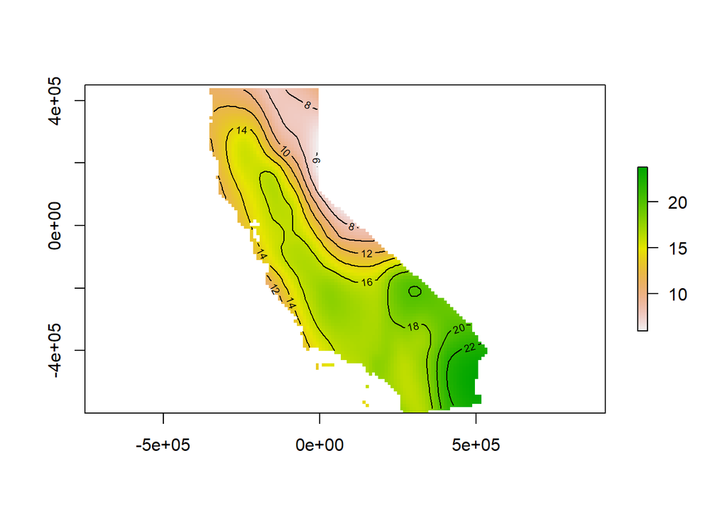

```r
m <- loess(temp ~ x + y, span=.2, data=train)
z <- interpolate(r, m)
zm <- mask(z, mask)
plot(zm)
contour(zm, add=TRUE)
```

```r
RMSE(predict(m, test), test$temp)
```

```
## [1] 2.053495
```

**Question 7:** What does the the `span` argument represent?

Span corresponds to the parameter $\alpha$, which controls the degree of smoothing. In other words, $\alpha$ controls the size of the neighborhood used for GWR as a proportion of the training data. Thus, $\alpha \geq 1$ corresponds to a global regression. In this example, since `span=.2`, we use $20\%$ of the data.

### Thin Plate Splines

```r
library(fields)
tps <- Tps(train[, c('x', 'y')], train$temp)
tps
```

```
## Call:
## Tps(x = train[, c("x", "y")], Y = train$temp)
##
##  Number of Observations:                242
##  Number of parameters in the null space 3
##  Parameters for fixed spatial drift     3
##  Model degrees of freedom:              229.9
##  Residual degrees of freedom:           12.1
##  GCV estimate for sigma:                0.2831
##  MLE for sigma:                         0.2578
##  MLE for rho:                           69200
##  lambda                                 9.6e-07
##  User supplied rho                      NA
##  User supplied sigma^2                  NA
## Summary of estimates:
##                  lambda       trA      GCV      shat -lnLike Prof converge
## GCV        9.606714e-07 229.90000 1.602401 0.2830549     536.8624       NA
## GCV.model            NA        NA       NA        NA           NA       NA
## GCV.one    9.606714e-07 229.90000 1.602401 0.2830549           NA       NA
## RMSE                 NA        NA       NA        NA           NA       NA
## pure error           NA        NA       NA        NA           NA       NA
## REML       2.973892e-04  69.19357 3.146969 1.4990581     507.1963        6
```

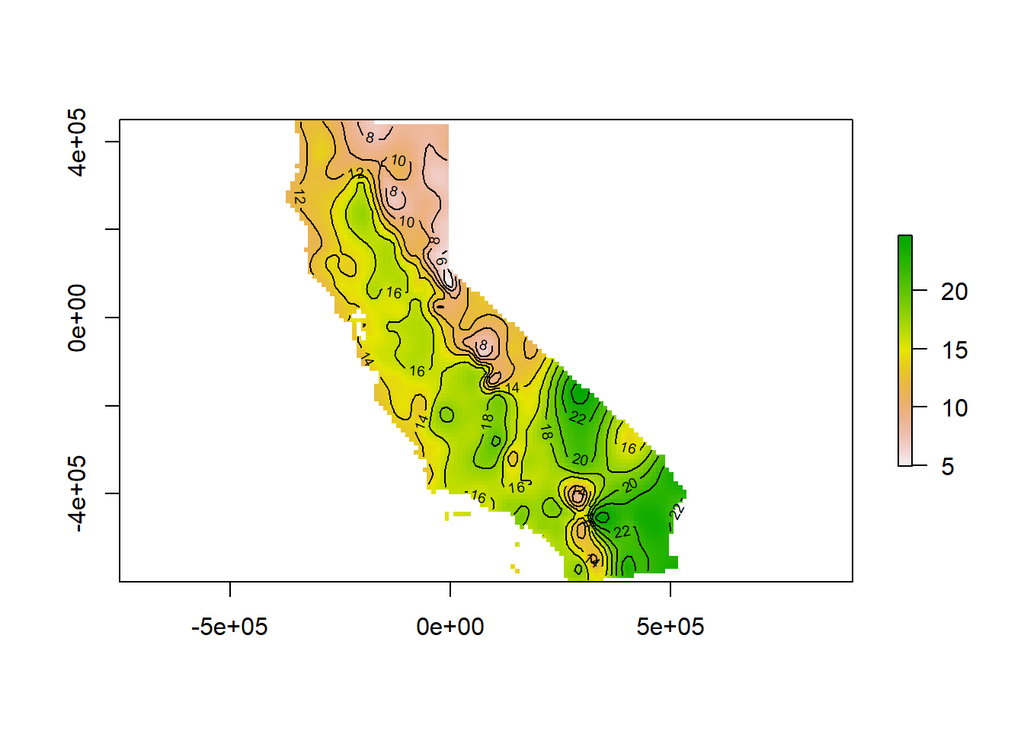

```r
# make predictions for the raster cells
ptps <- interpolate(r, tps)
ptps <- mask(ptps, mask)
plot(ptps)
contour(ptps, add=TRUE)
```

```r
# predict for the test points and get RMSE
pt <- predict(tps, test[, c('x', 'y')])
RMSE(pt, test$temp)
```

```
## [1] 2.167317
```

Now to add elevation as a co-variable:

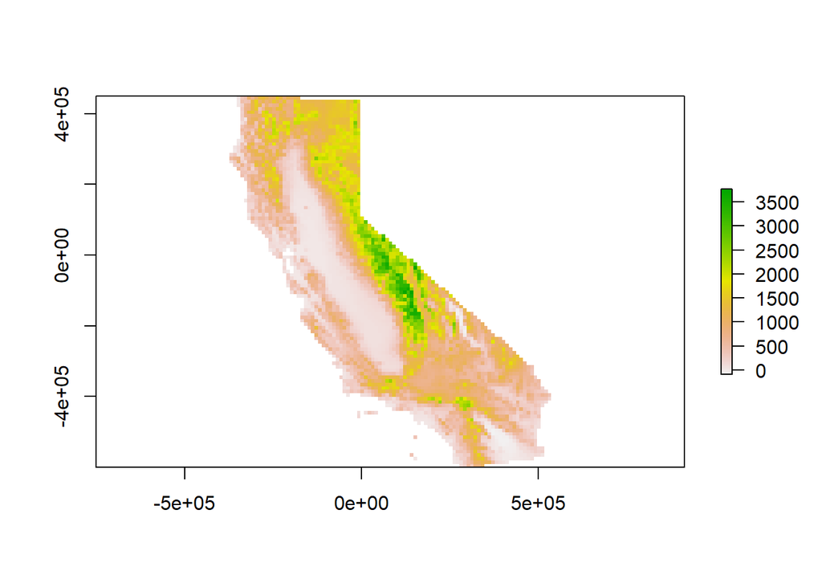

```r
# input elevation data
elv1 <- raster::getData('worldclim', res=0.5, var='alt', lon=-122, lat= 37)
elv2 <- raster::getData('worldclim', res=0.5, var='alt', lon=-120, lat= 37)
elv <- merge(elv1, elv2, overlap=FALSE)
# change projection
telv <- projectRaster(elv, r)
# mask the data to CA
celv <- mask(telv, mask)
names(celv) <- 'elevation'
# plot it
plot(celv)
```

```r
# add elecation variable to train and test data sets
train$elevation <- extract(celv, train[, 1:2])
test$elevation <- extract(celv, test[, 1:2])
# remove points with no elevation data
train <- train[!is.na(train$elevation), ]
test <- test[!is.na(test$elevation), ]
```

```r
# fit a thin plate spline with elevation now
tps2 <- Tps(train[, c('x', 'y', 'elevation')], train$temp)
```

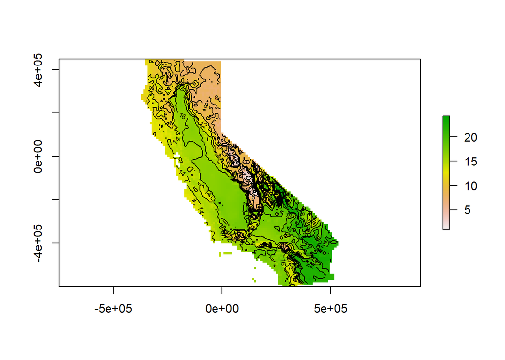

```r
# predict for grid cells
ptps2 <- interpolate(celv, tps2, xyOnly=FALSE)
# plot predictions with contours
plot(ptps2)
contour(ptps2, add=TRUE)
```

```r
# check error
pt2 <- predict(tps2, test[, c('x', 'y', 'elevation')])
RMSE(test$temp, pt2)
```

```
## [1] 1.762481
```

**Question 8:** What is a main reason that this the best prediction so far?

The main reason this is the best prediction so far is that we added another co-variable, and elevation is typically very relevant for prediction of temperature (i.e. temperature and elevation are often correlated).

### General Additive Models

```r
library(mgcv)
```

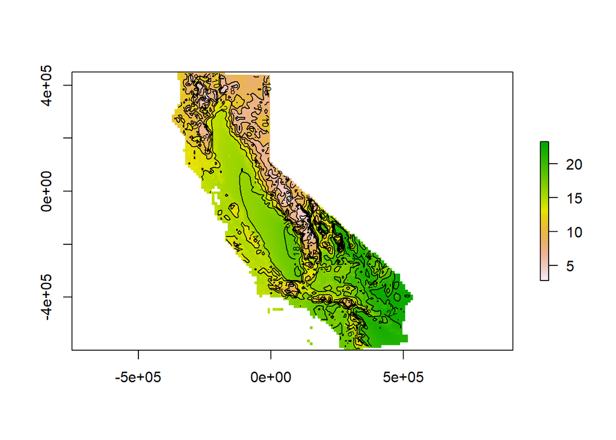

```r
ga <- gam(temp ~ s(x) + s(y) + s(elevation), data=train)
x <- interpolate(celv, ga, xyOnly=FALSE)
plot(x)
contour(x, add=TRUE)
```

```r
# get error for GAM
pg <- predict(ga, test)
RMSE(test$temp, pg)
```

```
## [1] 1.699617
```

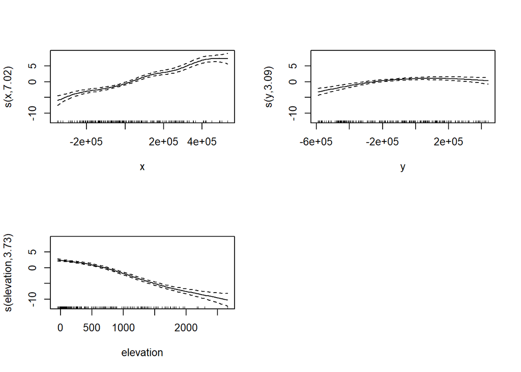

```r
# plot responses to variables
plot.gam(ga, pages=1)
```

**Question 9:** Use the help files to exaplin the model below. What do you think of it? Is it better or worse than the gam we did above?

```r
ga2 <- gam(temp ~ te(x, y, k=12, bs='ts') + s(elevation, bs='ts'), data=train)
```

This is a GAM with smoothing. It again models temperature as a function of `x`, `y`, and `elevation` with a smoothing penalty. The `bs='ts'` parameter indicates a thin plate spline with a modified smoothing penalty, such that the null space (values mapped to zero) are also penalized. The `k=12` term indicates a $12$ dimensional basis for the smoothing of coordinate response. Using `te` for both `x` and `y` instead of using `s` for each individually means that their responses are smoothed together rather than individually.

```r
pg2 <- predict(ga2, test)
RMSE(test$temp, pg2)
```

```
## [1] 1.571335
```

Seeing the computed RMSE above, we can conclude that this model performs better than the original GAM.